# Week 11

Group 3: Mara Alexeev, Parker Bannister, Mitchell Flagg

November 23, 2020

**Deliverables:**

Code available at our github repo: MaraAlexeev/720_regex_mmp

Error analysis of the top 10 false positive and false negative terms

Comparisons

Model Output

# Libraries

```r
#get relevant libraries
library(tidyverse)
library(magrittr)
library(forcats)
library(cvms)
library(tidyr)
library(tibble)
library(here)
library(ggimage)
library(rsvg)
library(text2vec)
library(data.table)
library(xgboost)
library(Matrix)
library(glmnet)
library(ROCR)
library(pROC)
library(caTools)
library(tm)
library(SnowballC)
library(tidygraph)
library(ggraph)
library(igraph)
```

# Functions

## Load data files

```r
covidclass_70percentlabels <- read.table("data_do_not_alter/covidclass_70percentlabels.csv",  na.strings = "", header = TRUE, sep = "|", quote = "", comment.char = "", col.names = c("id", "chief_complaint_1", "chief_complaint_2", "thirty_label", "seventy_label"))

cclist <- read_delim("ontology/presentingproblem/CCList.tsv",
    "\t", escape_double = FALSE, trim_ws = TRUE)

qalist <- read_delim("ontology/presentingproblem/QAList.tsv",
    "\t", escape_double = FALSE, trim_ws = TRUE)

concepts <- read_delim("ontology/presentingproblem/concepts.tsv",
    "\t", escape_double = FALSE, trim_ws = TRUE)

relationship <- read_delim("ontology/presentingproblem/relationship.tsv",
    "\t", escape_double = FALSE, trim_ws = TRUE)
```

## Clean Data

```r
#Cleaning rows 4010 and 6713 with extra quotation marks
covidclass_70percentlabels[4010,1] <- 4010
covidclass_70percentlabels[4010,5] <- 0
covidclass_70percentlabels[6713,1] <- 6713
covidclass_70percentlabels[6713,5] <- 0

#Making empty chief complaint clearer
covidclass_70percentlabels$chief_complaint_1[which(is.na(covidclass_70percentlabels$chief_complaint_1))] <-  "No CC provided"

covidclass_70percentlabels$id <- as.numeric(covidclass_70percentlabels$id)

#Clean column names and drop unneeded columns

covid_dataset <- covidclass_70percentlabels %>%
   mutate(covid_label = case_when(
    seventy_label == "0" ~ 0,
    seventy_label == "1" ~ 1
  )) %>%
  rename(cc = chief_complaint_1) %>%
  select(c("id", "cc", "covid_label"))
```

# New Concept mapping

Must keep the final dataset named covid_dataset to work with further analysis code below.

```r
##########
#turn chief complaint into ontology terms:

covid_dataset$cc <- as.character(covid_dataset$cc)

#join cleaned terms with qalist misspelled ontology terms
covid_dataset %<>% left_join(qalist, by=c('cc' = 'description'), ignore_case = TRUE)

#join previous result with classic ontology terms
covid_dataset %<>%  left_join(cclist, by=c('cc' = 'description'), ignore_case = TRUE)

#get one column with term and one column with concept ID:
covid_dataset %<>%
  mutate(ontology_term = case_when(
      is.na(defaultDescription.x) ~ defaultDescription.y,
      TRUE                         ~ defaultDescription.x
    )
  )

covid_dataset %<>%
  mutate(ontology_id = case_when(
      is.na(conceptID.x) ~ conceptID.y,
      TRUE              ~ conceptID.x
    )
  )

#clean concept IDs to remove laterality and re-map cleaned IDs to base ontology concepts
covid_dataset$ontology_id <- gsub( "-L", "", covid_dataset$ontology_id)
covid_dataset$ontology_id <- gsub( "-R", "", covid_dataset$ontology_id)
covid_dataset$ontology_id <- gsub( "-B", "", covid_dataset$ontology_id)

#remap to ontology concepts:
covid_dataset %<>% left_join(concepts, by=c('ontology_id' = 'conceptID'), ignore_case = TRUE)

#clean unmapped terms to base chief complaint:
covid_dataset %<>%
  mutate(defaultDescription = case_when(
      is.na(defaultDescription) ~ cc,
      TRUE              ~ defaultDescription
    )
  )

#reduce to vital information and clean for model ingestion:
covid_dataset %<>%  select(id, defaultDescription, ontology_id, covid_label)

colnames(covid_dataset) <- c('id', 'cc', 'ontology_id_base', 'covid_label')

#Making empty chief complaint clearer
covid_dataset$cc[which(is.na(covid_dataset$cc))] <-  "No CC provided"

covid_dataset$ontology_id_base <- as.numeric(covid_dataset$ontology_id_base)
ontology_bins <- covid_dataset %>%
  dplyr::group_by(ontology_id_base, cc) %>%
  summarise(count = n()) %>%
  arrange(desc(count))
ontology_bins
```

```
## # A tibble: 379 x 3
## # Groups:   ontology_id_base [286]
##    ontology_id_base cc                    count
##               <dbl> <chr>                 <int>
##  1         21522001 Abd pain               1010
##  2        267036007 Dyspnea                 755
##  3         29857009 Chest pain              711
##  4        386661006 Fever                   433
##  5        419284004 Altered mental status   312
##  6         49727002 Cough                   302
##  7        442096005 Abnormal labs           290
##  8        161898004 s/p Fall                250
##  9        404640003 Dizziness               172
## 10         26544005 Weakness                162
## # ... with 369 more rows
```

```r
examine_missing_ontology <- ontology_bins %>%
  filter(is.na(ontology_id_base))

examine_missing_ontology
```

```
## # A tibble: 94 x 3
## # Groups:   ontology_id_base [1]
##    ontology_id_base cc                       count
##               <dbl> <chr>                    <int>
##  1               NA No CC provided              25
##  2               NA Wound eval                  20
##  3               NA ABN LAB VALUES              13
##  4               NA Epigastric pain             10
##  5               NA ABN CT                       9
##  6               NA Fatigue                      9
##  7               NA TRAUMATIC BACK/SPINE INJ     9
##  8               NA #NAME?                       8
##  9               NA Agitation                    7
## 10               NA Decreased PO intake          7
## # ... with 84 more rows
```

```r
find_my_parent <- function(id) {
  parent <- relationship %>%
    dplyr::filter(childID == id) %>%
    dplyr::select(parentID)



  return(parent[[1, 1]])
}

find_my_parent(315596001)
```

```
## [1] 118937003
```

```r
do_i_have_a_parent <- function(id) {
  parent_count <- relationship %>%
    dplyr::filter(childID == id) %>%
    nrow()


  return(parent_count > 0)
}

do_i_have_a_parent(736004
)
```

```
## [1] TRUE
```

```r
grandest_parent <- function(id) {
  if(do_i_have_a_parent(id)) {
    return(grandest_parent(find_my_parent(id)))
  }
  else{
    return(id)
  }
}

grandest_parent(250171008)
```

```
## [1] 404684003
```

```r
#Create top_parent from above data (takes a really long time, saved as csv and then loaded instead)
# top_parent <- covid_dataset %>%
#   rowwise() %>%
#   mutate(top_parent_id = grandest_parent(ontology_id_base))


#write_csv(top_parent, "./ontology/top_parent.csv")

top_parent <- read_csv("ontology/top_parent.csv")
#to work with analysis pipeline need dataset to be called covid_dataset
covid_dataset <- top_parent
```

## Create labeled datasets

```r
labeled_data <- covid_dataset %>%
  filter(!is.na(covid_label))

labeled_data_for_glmnet <- labeled_data
```

## xgboost analysis pipeline

# Create a corpus for labeled data

```r
#https://www.pluralsight.com/guides/machine-learning-text-data-using-r

corpus <-  Corpus(VectorSource(labeled_data$cc))
corpus[[1]][1]
```

```
## $content
## [1] "Dyspnea"
```

```r
corpus <-  tm_map(corpus, PlainTextDocument)
corpus  <-  tm_map(corpus, tolower)
corpus <- tm_map(corpus, removePunctuation)
corpus[[1]][1]
```

```
## $content
## [1] "dyspnea"
```

```r
corpus <-  tm_map(corpus, removeWords, c(stopwords("english")))
corpus[[1]][1]
```

```
## $content
## [1] "dyspnea"
```

```r
corpus <-  tm_map(corpus, stemDocument)
corpus[[1]][1]
```

```
## $content
## [1] "dyspnea"
```

```r
frequencies  <-  DocumentTermMatrix(corpus)

#Choose value for your sparse terms cutoff
sparse_term_cutoff <- 0.995

sparse <-  removeSparseTerms(frequencies, sparse_term_cutoff)

tSparse <-  as.data.frame(as.matrix(sparse))
colnames(tSparse) <-  make.names(colnames(tSparse))

columns_to_keep <- colnames(tSparse)

# Add back ontology columns and covid_label to sparse term dataframe
tSparse$covid_label <-  labeled_data$covid_label
tSparse$ontology_id_base <-  labeled_data$ontology_id_base
tSparse$top_parent_id <-  labeled_data$top_parent_id
```

## Test and Train data for xgboost

```r
set.seed(888)
split  <-  sample.split(tSparse$covid_label, SplitRatio = 0.7)
trainSparse  <-  subset(tSparse, split==TRUE)
testSparse <-  subset(tSparse, split==FALSE)
```

## Non linear model with xgboost

### Train model

```r
#Drop the covid_label from being in the training
data_matrix <- as.matrix(trainSparse[,colnames(trainSparse) != "covid_label"])
output_vector  <-  as.matrix(trainSparse[,"covid_label"])

bst <- xgboost(data = data_matrix, label = output_vector, scale_pos_weight = 20, nrounds = 20,objective = "binary:logistic")
```

### Use test data

```r
data_matrix_test <- as.matrix(testSparse[,colnames(testSparse) != "covid_label"])

pred <- predict(bst, data_matrix_test)


# Pick a prediction cutoff
prediction_cutoff <- 0.5
prediction <- as.numeric(pred > prediction_cutoff)
```

```r
test_data <- data.frame(testSparse)
test_data <- rownames_to_column(test_data, var = "id")
prediction <- data.frame(prediction)

data_and_prediction <-cbind(test_data, prediction)

small_d_and_p <- data_and_prediction %>%
  select("id", "prediction", "covid_label", "ontology_id_base", "top_parent_id")

#Small confusion matrix
table(small_d_and_p$prediction, small_d_and_p$covid_label)
```

```
##
##        0    1
##   0 1070   43
##   1  771   77
```

```r
corpus_f <-  Corpus(VectorSource(covid_dataset$cc))

corpus_f <-  tm_map(corpus_f, PlainTextDocument)
corpus_f  <-  tm_map(corpus_f, tolower)
corpus_f <- tm_map(corpus_f, removePunctuation)
corpus_f <-  tm_map(corpus_f, removeWords, c(stopwords("english")))
corpus_f <-  tm_map(corpus_f, stemDocument)
frequencies_f  <-  DocumentTermMatrix(corpus_f)

frequencies_f_all_columns <-  as.data.frame(as.matrix(frequencies_f))

full_data_top_columns <- frequencies_f_all_columns %>%
  select(columns_to_keep)
```

```
## Note: Using an external vector in selections is ambiguous.
## i Use `all_of(columns_to_keep)` instead of `columns_to_keep` to silence this message.
## i See <https://tidyselect.r-lib.org/reference/faq-external-vector.html>.
```

```r
full_data_top_columns$covid_label <-  (covid_dataset$covid_label)
full_data_top_columns$ontology_id_base <-  covid_dataset$ontology_id_base
full_data_top_columns$top_parent_id <-  covid_dataset$top_parent_id

data_matrix_full <- as.matrix(full_data_top_columns[,colnames(full_data_top_columns) != "covid_label"])

pred_full <- predict(bst, data_matrix_full)
pred_full <- data.frame(pred_full)
```

## Predicted probabilities and cutoff

```r
covid_dataset$model_predictions <- pred_full$pred_full

covid_dataset <- covid_dataset %>%
  mutate(final_predictions = case_when(
    model_predictions >= prediction_cutoff ~ 1,
    model_predictions < prediction_cutoff ~ 0,
  ))

predictions_errors <- covid_dataset %>%
  filter(!is.na(covid_label))

table(predictions_errors$covid_label, predictions_errors$final_predictions)
```

```
##
##        0    1
##   0 3595 2543
##   1   95  306
```

## ROC curves

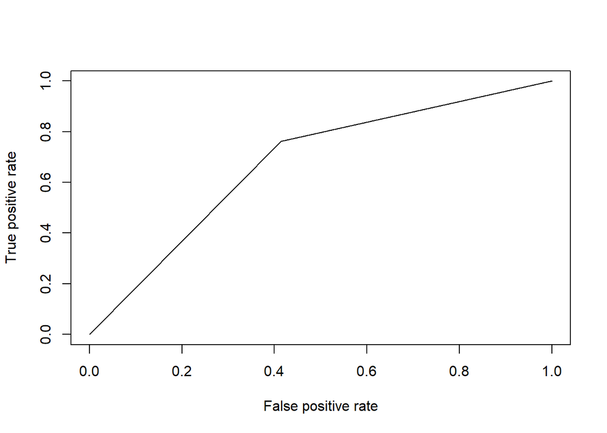

```r
prediction_xgboost_model <- prediction(predictions_errors$final_predictions, predictions_errors$covid_label)

performance_xgboost_model <- performance(prediction_xgboost_model,"tpr","fpr")
plot(performance_xgboost_model,colorize=FALSE)
```

```r
model_xgboost <- data.frame("target" = c(predictions_errors$covid_label),
                                  "prediction"= c(predictions_errors$final_predictions))

model_eval_model_xgboost <- evaluate(model_xgboost,
                 target_col = "target",
                 prediction_col = "prediction",
                 type = "binomial")
```

# Linear Model with glmnet analysis pipeline

```r
#Using text2vec example as guide

# Labeled data with week 6 predictions

#Transform to data.table set key to id
glmnet_covid_dataset <- setDT(labeled_data_for_glmnet)

setkey(glmnet_covid_dataset, id)

#Set seed and divid data with labels into test and train data
set.seed(888)
all_ids <-  glmnet_covid_dataset$id
train_ids <- sample(all_ids, 1300)
test_ids <- setdiff(all_ids, train_ids)

train_glm <-  glmnet_covid_dataset[J(train_ids)]
test_glm <-  glmnet_covid_dataset[J(test_ids)]
```

### Vectorization

```r
# define preprocessing function and tokenization function
prep_fun <-  tolower
tok_fun <-  word_tokenizer

it_train_glm <- itoken(train_glm$cc,
             preprocessor = prep_fun,
             tokenizer = tok_fun,
             ids = train_glm$id,
             progressbar = FALSE)

vocab_glm <- create_vocabulary(it_train_glm)
```

### Create Document Term Matrix

```r
vectorizer_glm <- vocab_vectorizer(vocab_glm)

dtm_train_glm  <-  create_dtm(it_train_glm, vectorizer_glm)
```

### Fit first model

```r
NFOLDS <-  4

glmnet_classifier <-  cv.glmnet(x = dtm_train_glm, y = train_glm[['covid_label']],
                              family = 'binomial',
                              # L1 penalty
                              alpha = 1,
                              # interested in the area under ROC curve
                              type.measure = "auc",
                              # 5-fold cross-validation
                              nfolds = NFOLDS,
                              # high value is less accurate, but has faster training
                              thresh = 1e-3,
                              # again lower number of iterations for faster training
                              maxit = 1e3)
```

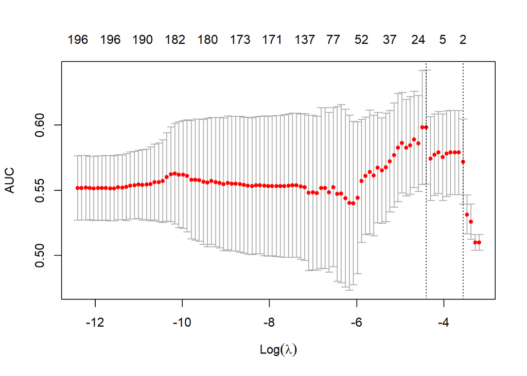

```r
plot(glmnet_classifier)
```

### Trying model on test data

```r
it_test_glm <-  tok_fun(prep_fun(test_glm$cc))

it_test_glm  <-  itoken(it_test_glm, ids = test_glm$id, progressbar = FALSE)


dtm_test_glm <-  create_dtm(it_test_glm, vectorizer_glm)

preds_glm  <-  predict(glmnet_classifier, dtm_test_glm, type = 'response')[,1]
```

```r
predict_table_glm <-  data.frame(preds_glm)
predict_with_id <- rownames_to_column(predict_table_glm, var = "id")
predict_with_id$id <- as.numeric(predict_with_id$id)
predict_w_id_status <-  predict_with_id %>%
  left_join(labeled_data_for_glmnet, by = "id")
```

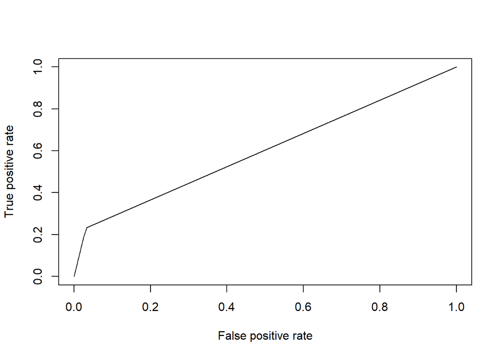

```r
#Source https://rviews.rstudio.com/2019/03/01/some-r-packages-for-roc-curves/

pred_glm <- prediction(predict_w_id_status$preds_glm, predict_w_id_status$covid_label)
perf_glm <- performance(pred_glm,"tpr","fpr")
plot(perf_glm,colorize=FALSE)
```

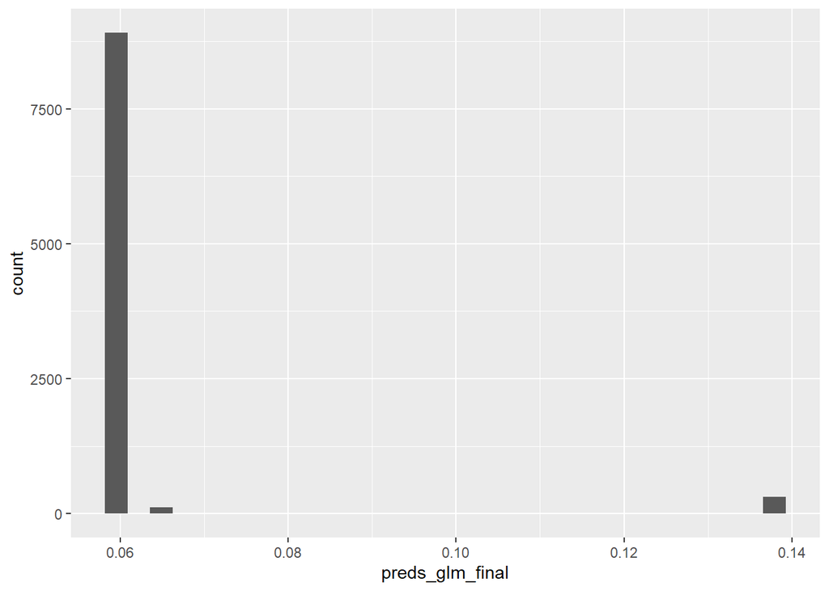

```r
preds_glm_final <-  tok_fun(prep_fun(covid_dataset$cc))

preds_glm_final  <-  itoken(preds_glm_final, ids = preds_glm_final$id, progressbar = FALSE)


dtm_week_glm_final <-  create_dtm(preds_glm_final, vectorizer_glm)

preds_glm_final  <-  predict(glmnet_classifier, dtm_week_glm_final, type = 'response')[,1]

preds_glm_final <-  data.frame(preds_glm_final)
preds_glm_final <- rownames_to_column(preds_glm_final, var = "id")
preds_glm_final$id <- as.numeric(preds_glm_final$id)
preds_glm_final <-  preds_glm_final %>%
  left_join(labeled_data_for_glmnet, by = "id")

plot_glm_final <- preds_glm_final %>%
  ggplot(aes(preds_glm_final)) + geom_histogram()

plot_glm_final
```

```r
summary(preds_glm_final$preds_glm_final)
```

```
##    Min. 1st Qu.  Median    Mean 3rd Qu.    Max.
## 0.06009 0.06009 0.06009 0.06273 0.06009 0.13851
```

```r
cutoff_glm <- 0.061
```

We choose 0.061 as the cutoff for labeling a chief complaint as positive.

```r
preds_glm_final <- preds_glm_final %>%
  mutate(covid_prediction_glm =
           case_when(
             preds_glm_final < cutoff_glm ~ 0,
             preds_glm_final >= cutoff_glm ~ 1
           )
         )
```

```r
model_eval_model_glm <- preds_glm_final %>%
  filter(covid_label == 0 | covid_label == 1)

model_eval_model_glm_table <- data.frame("target" = c(model_eval_model_glm$covid_label),
                                  "prediction"= c(model_eval_model_glm$covid_prediction_glm))

model_eval_model_glm_table <- evaluate(model_eval_model_glm_table,
                 target_col = "target",
                 prediction_col = "prediction",
                 type = "binomial")
```

# Comparisons

```r
model_eval_model_xgboost[,1:7]
```

```
## # A tibble: 1 x 7
##   `Balanced Accur~ Accuracy    F1 Sensitivity Specificity `Pos Pred Value`
##              <dbl>    <dbl> <dbl>       <dbl>       <dbl>            <dbl>
## 1            0.674    0.597 0.188       0.763       0.586            0.107
## # ... with 1 more variable: `Neg Pred Value` <dbl>
```

```r
model_eval_model_glm_table[,1:7]
```

```
## # A tibble: 1 x 7
##   `Balanced Accur~ Accuracy    F1 Sensitivity Specificity `Pos Pred Value`
##              <dbl>    <dbl> <dbl>       <dbl>       <dbl>            <dbl>
## 1            0.598    0.921 0.264       0.229       0.967            0.310
## # ... with 1 more variable: `Neg Pred Value` <dbl>
```

## Prior weeks

### Week 8 results on test:

- sensitivity 0.285714286
- specificity 0.864125122
- PPV 0.122105263
- NPV 0.948158742
- accuracy 0.828239609
- f1 0.171091445

### Week 10

Linear Model Training Data (6539 rows with the labels you were provided) sensitivity 0.229426434 specificity 0.966601499 PPV 0.30976431 NPV 0.950496636 accuracy 0.921394709 f1 0.263610315

Test/Holdout Data (2793 rows of the remaining data whose “ground truth” labels you were NOT provided) sensitivity 0.2 specificity 0.964163172 PPV 0.265625 NPV 0.948968105 accuracy 0.917651271 f1 0.228187919

Non-Linear Model (XGBoost) Training Data (6539 rows with the labels you were provided) sensitivity 0.593516209 specificity 0.766373412 PPV 0.142344498 NPV 0.966509143 accuracy 0.755773054 f1 0.22961891

Reported Training AUC ROC = 0.680

Test/Holdout Data (2793 rows of the remaining data whose “ground truth” labels you were NOT provided) sensitivity 0.570588235 specificity 0.777735417 PPV 0.142647059 NPV 0.965451964 accuracy 0.765127103 f1 0.228235294

Holdout AUC ROC = 0.697

```r
model_eval_model_glm_table[[18]]
```

```
## [[1]]
## # A tibble: 4 x 5
##   Prediction Target Pos_0 Pos_1     N
##   <chr>      <chr>  <chr> <chr> <int>
## 1 0          0      TP    TN     5933
## 2 1          0      FN    FP      205
## 3 0          1      FP    FN      309
## 4 1          1      TN    TP       92
```

```r
model_eval_model_xgboost[[18]]
```

```
## [[1]]
## # A tibble: 4 x 5
##   Prediction Target Pos_0 Pos_1     N
##   <chr>      <chr>  <chr> <chr> <int>
## 1 0          0      TP    TN     3595
## 2 1          0      FN    FP     2543
## 3 0          1      FP    FN       95
## 4 1          1      TN    TP      306
```

```r
model_eval_model_glm_table[[17]]
```

```
## $`1`
##
## Call:
## roc.default(response = targets, predictor = predicted_probabilities,     levels = levels, direction = direction)
##
## Data: predicted_probabilities in 6138 controls (targets 0) < 401 cases (targets 1).
## Area under the curve: 0.598
```

```r
model_eval_model_xgboost[[17]]
```

```
## $`1`
##
## Call:
## roc.default(response = targets, predictor = predicted_probabilities,     levels = levels, direction = direction)
##
## Data: predicted_probabilities in 6138 controls (targets 0) < 401 cases (targets 1).
## Area under the curve: 0.6744
```

# Error Analysis

## xgboost errors

```r
error_analysis <- predictions_errors %>%
 mutate(results =  case_when(
    covid_label == 0 & final_predictions == 0 ~ "True Negative",
    covid_label == 1 & final_predictions == 1 ~ "True Positive",
    covid_label == 0 & final_predictions == 1 ~ "False Positive",
    covid_label == 1 & final_predictions == 0 ~ "False Negative"
  ))
```

```r
tp_model_1 <- cc_by_results(error_analysis, "True Positive")
```

```
## # A tibble: 10 x 3
## # Groups:   results [1]
##    results       cc                    count
##    <chr>         <chr>                 <int>
##  1 True Positive Cough                    70
##  2 True Positive Dyspnea                  46
##  3 True Positive Fever                    42
##  4 True Positive ILI                      22
##  5 True Positive Hypoxia                  17
##  6 True Positive Altered mental status    13
##  7 True Positive Body aches               10
##  8 True Positive Abnormal labs             9
##  9 True Positive Weakness                  8
## 10 True Positive Diarrhea                  7
```

```r
tn_model_1 <- cc_by_results(error_analysis, "True Negative")
```

```
## # A tibble: 10 x 3
## # Groups:   results [1]
##    results       cc         count
##    <chr>         <chr>      <int>
##  1 True Negative Abd pain     700
##  2 True Negative Chest pain   468
##  3 True Negative Back pain    103
##  4 True Negative Headache      99
##  5 True Negative SI            88
##  6 True Negative Wound eval    74
##  7 True Negative N/V           68
##  8 True Negative Confusion     65
##  9 True Negative BRBPR         61
## 10 True Negative Leg pain      61
```

```r
fp_model_1 <- cc_by_results(error_analysis, "False Positive")
```

```
## # A tibble: 10 x 3
## # Groups:   results [1]
##    results        cc                    count
##    <chr>          <chr>                 <int>
##  1 False Positive Dyspnea                 506
##  2 False Positive Fever                   258
##  3 False Positive Altered mental status   205
##  4 False Positive Abnormal labs           192
##  5 False Positive s/p Fall                172
##  6 False Positive Cough                   141
##  7 False Positive Dizziness               109
##  8 False Positive Weakness                 98
##  9 False Positive Diarrhea                 69
## 10 False Positive ILI                      60
```

```r
fn_model_1 <- cc_by_results(error_analysis, "False Negative")
```

```
## # A tibble: 10 x 3
## # Groups:   results [1]
##    results        cc          count
##    <chr>          <chr>       <int>
##  1 False Negative Chest pain     19
##  2 False Negative Abd pain       16
##  3 False Negative Back pain       6
##  4 False Negative Headache        5
##  5 False Negative Confusion       3
##  6 False Negative Hypotension     3
##  7 False Negative BRBPR           2
##  8 False Negative Fatigue         2
##  9 False Negative Leg pain        2
## 10 False Negative N/V             2
```

```r
all_results_model_1 <- bind_rows(tp_model_1, tn_model_1, fp_model_1, fn_model_1)

all_results_model_1_wide <- pivot_wider(all_results_model_1, names_from = results, values_from = count, values_fill = 0)
```

## glm error analysis

```r
error_analysis_glm <- model_eval_model_glm %>%
 mutate(results =  case_when(
    covid_label == 0 & covid_prediction_glm == 0 ~ "True Negative",
    covid_label == 1 & covid_prediction_glm == 1 ~ "True Positive",
    covid_label == 0 & covid_prediction_glm == 1 ~ "False Positive",
    covid_label == 1 & covid_prediction_glm == 0 ~ "False Negative"
  ))
```

```r
tp_model_glm <- cc_by_results(error_analysis_glm, "True Positive")
```

```
## # A tibble: 2 x 3
## # Groups:   results [1]
##   results       cc    count
##   <chr>         <chr> <int>
## 1 True Positive Cough    70
## 2 True Positive ILI      22
```

```r
tn_model_glm <- cc_by_results(error_analysis_glm, "True Negative")
```

```
## # A tibble: 10 x 3
## # Groups:   results [1]
##    results       cc                    count
##    <chr>         <chr>                 <int>
##  1 True Negative Abd pain                700
##  2 True Negative Dyspnea                 506
##  3 True Negative Chest pain              468
##  4 True Negative Fever                   258
##  5 True Negative Altered mental status   205
##  6 True Negative Abnormal labs           192
##  7 True Negative s/p Fall                172
##  8 True Negative Dizziness               109
##  9 True Negative Back pain               103
## 10 True Negative Headache                 99
```

```r
fp_model_glm <- cc_by_results(error_analysis_glm, "False Positive")
```

```
## # A tibble: 3 x 3
## # Groups:   results [1]
##   results        cc               count
##   <chr>          <chr>            <int>
## 1 False Positive Cough              141
## 2 False Positive ILI                 60
## 3 False Positive Productive cough     4
```

```r
fn_model_glm <- cc_by_results(error_analysis_glm, "False Negative")
```

```
## # A tibble: 10 x 3
## # Groups:   results [1]
##    results        cc                    count
##    <chr>          <chr>                 <int>
##  1 False Negative Dyspnea                  46
##  2 False Negative Fever                    42
##  3 False Negative Chest pain               19
##  4 False Negative Hypoxia                  17
##  5 False Negative Abd pain                 16
##  6 False Negative Altered mental status    13
##  7 False Negative Body aches               10
##  8 False Negative Abnormal labs             9
##  9 False Negative Weakness                  8
## 10 False Negative Diarrhea                  7
```

# Model outputs

## xgboost model Output

```r
#Our COVID prediction is labeled in the column final_predictions
#Our COVID prediction raw probablity is in the column labeled final_predictions preds_glm_final
group3_predictions_wk11_xgboost <-  covid_dataset
write_csv(group3_predictions_wk11_xgboost, "./analysis/group3_predictions_wk11_xgboost.csv")
```

## glm model Output

```r
#Our COVID prediction is labeled in the column final_predictions
group3_predictions_wk11_glm <- preds_glm_final
write_csv(group3_predictions_wk11_glm, "./analysis/group3_predictions_wk11_glm.csv")
```